# Tp-Titanic

Marjan BABAKI

2026-11-12

### Loading the dataset

```r
df <- carData::TitanicSurvival
head(df)
```

```
##                                 survived    sex     age passengerClass
## Allen, Miss. Elisabeth Walton        yes female 29.0000            1st
## Allison, Master. Hudson Trevor       yes   male  0.9167            1st
## Allison, Miss. Helen Loraine          no female  2.0000            1st
## Allison, Mr. Hudson Joshua Crei       no   male 30.0000            1st
## Allison, Mrs. Hudson J C (Bessi       no female 25.0000            1st
## Anderson, Mr. Harry                  yes   male 48.0000            1st
```

```r
summary(df)
```

```
##  survived      sex           age          passengerClass
##  no :809   female:466   Min.   : 0.1667   1st:323
##  yes:500   male  :843   1st Qu.:21.0000   2nd:277
##                         Median :28.0000   3rd:709
##                         Mean   :29.8811
##                         3rd Qu.:39.0000
##                         Max.   :80.0000
##                         NAs    :263
```

Les donnees `TitanicSurvival` du package **carData** decrivent 1 309 passagers. Chaque ligne correspond a un passager : survie (`survived`), sexe (`sex`), age en annees (`age`) et classe (`passengerClass`). L’equipage n’est pas inclus.

### Descriptive statistics

```r
nrow(df)
```

```
## [1] 1309
```

```r
colSums(is.na(df))
```

```
##       survived            sex            age passengerClass
##              0              0            263              0
```

```r
table(df$survived)
```

```
##
##  no yes
## 809 500
```

```r
table(df$sex)
```

```
##
## female   male
##    466    843
```

```r
table(df$passengerClass)
```

```
##
## 1st 2nd 3rd
## 323 277 709
```

```r
summary(df$age)
```

```
##    Min. 1st Qu.  Median    Mean 3rd Qu.    Max.     NAs
##  0.1667 21.0000 28.0000 29.8811 39.0000 80.0000     263
```

L’age est manquant pour 263 passagers. Ces observations restent incluses dans les taux de survie par sexe et par classe ; seules les valeurs d’age observees sont utilisees pour le graphique d’age.

### Overall survival rate

```r
taux_global <- mean(df$survived == "yes") * 100
taux_global
```

```
## [1] 38.1971
```

### Survival counts by sex

```r
survie_sexe <- table(Sexe = df$sex, Survie = df$survived)
survie_sexe
```

```
##         Survie
## Sexe      no yes
##   female 127 339
##   male   682 161
```

### Survival rate by sex

```r
taux_sexe <- prop.table(survie_sexe, margin = 1) * 100
round(taux_sexe, 2)
```

```
##         Survie
## Sexe        no   yes
##   female 27.25 72.75
##   male   80.90 19.10
```

### Survival rate by class

```r
survie_classe <- table(Classe = df$passengerClass, Survie = df$survived)
survie_classe
```

```
##       Survie
## Classe  no yes
##    1st 123 200
##    2nd 158 119
##    3rd 528 181
```

```r
taux_classe <- prop.table(survie_classe, margin = 1) * 100
round(taux_classe, 2)
```

```
##       Survie
## Classe    no   yes
##    1st 38.08 61.92
##    2nd 57.04 42.96
##    3rd 74.47 25.53
```

### Graph: Survival by sex

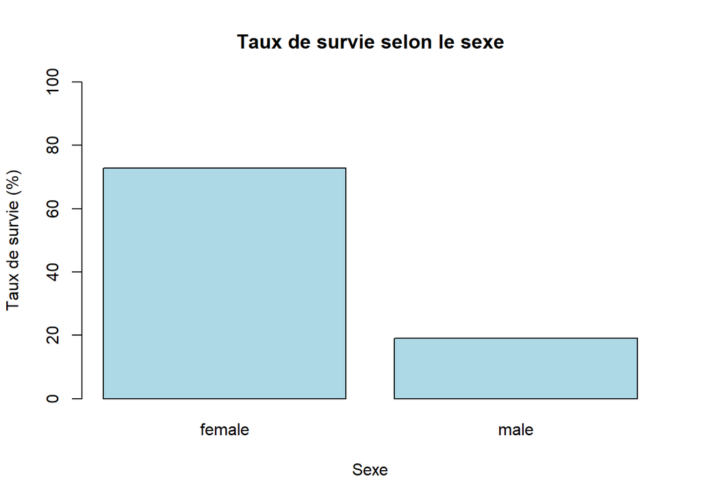

```r
barplot(taux_sexe[, "yes"],
        main = "Taux de survie selon le sexe", xlab = "Sexe",
        ylab = "Taux de survie (%)", col = "lightblue", ylim = c(0, 100))
```

### Graph: Survival by class

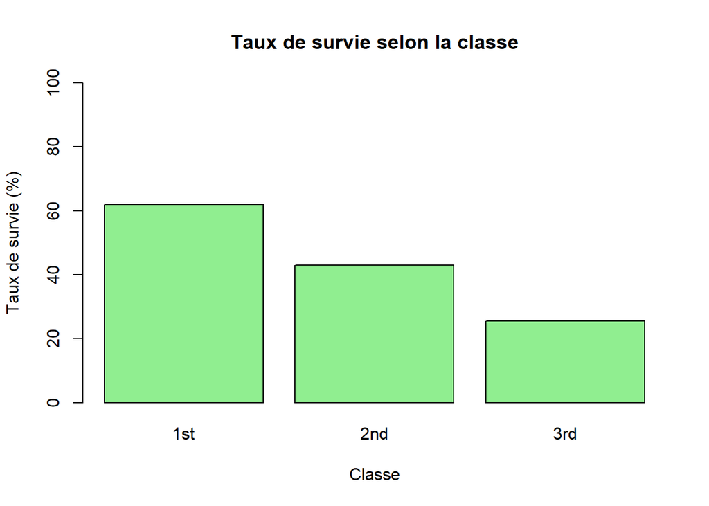

```r
barplot(taux_classe[, "yes"],
        main = "Taux de survie selon la classe", xlab = "Classe",
        ylab = "Taux de survie (%)", col = "lightgreen", ylim = c(0, 100))
```

### Graph: Age by survival

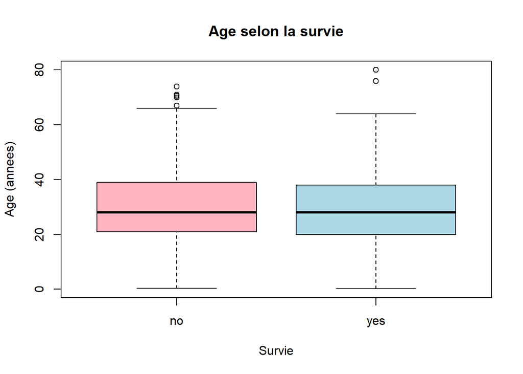

```r
boxplot(age ~ survived, data = df,
        main = "Age selon la survie", xlab = "Survie", ylab = "Age (annees)",
        col = c("lightpink", "lightblue"))
```

```r
tapply(df$age, df$survived, median, na.rm = TRUE)
```

```
##  no yes
##  28  28
```

## Interpretation des resultats

**Survie selon le sexe :** les femmes avaient un taux de survie nettement superieur a celui des hommes (72.7 % contre 19.1 %).

**Survie selon la classe :** les taux sont de 61.9 % en premiere classe, 43 % en deuxieme classe et 25.5 % en troisieme classe.

**Age selon la survie :** parmi les ages observes, l’age median est de 28 ans chez les survivants et de 28 ans chez les non-survivants. Les distributions se chevauchent et les ages manquants limitent l’interpretation.

**Conclusion :** la survie varie selon le sexe et la classe. Le graphique permet aussi de comparer les ages observes selon la survie. Ces resultats sont descriptifs et ne permettent pas d’etablir des relations de cause a effet.

## Survival rates using TitanicPackage

Les fonctions du package utilisent les memes donnees et renvoient des proportions ; on les multiplie par 100 pour afficher des pourcentages.

```r
library(TitanicPackage)
round(taux_survie_sex(df) * 100, 2)
```

```
## female   male
##  72.75  19.10
```

```r
round(taux_survie_class(df) * 100, 2)
```

```
##   1st   2nd   3rd
## 61.92 42.96 25.53
```